# E-Commerce Retail Sales Analysis

This project analyzes an online retail dataset to understand sales performance, customer behavior, and revenue trends.  
The analysis focuses on identifying top-performing products, key revenue-generating markets, purchasing patterns, and customer segments using data analytics techniques.

Tools Used:

- Python
- Pandas
- NumPy
- Matplotlib
- Seaborn

Objectives:

- Understand overall sales performance
- Identify top products and countries by revenue
- Analyze monthly sales trends
- Segment customers using RFM analysis

### Import Libraries

```python
import pandas as pd
import numpy as np
import matplotlib.pyplot as plt
import seaborn as sns
```

```python
import os
os.getcwd()
```

```
'C:\\Users\\Hardik'
```

### Load Dataset

```python
df = pd.read_csv("online retail clean.csv")
df.head()
```

|  | InvoiceNo | StockCode | Description | Quantity | InvoiceDate | UnitPrice | CustomerID | Country | Revenue |
| --- | --- | --- | --- | --- | --- | --- | --- | --- | --- |
| 0 | 536365 | 85123A | WHITE HANGING HEART T-LIGHT HOLDER | 6 | 01-12-2010 08:26 | 2.55 | 17850 | United Kingdom | 15.30 |
| 1 | 536365 | 71053 | WHITE METAL LANTERN | 6 | 01-12-2010 08:26 | 3.39 | 17850 | United Kingdom | 20.34 |
| 2 | 536365 | 84406B | CREAM CUPID HEARTS COAT HANGER | 8 | 01-12-2010 08:26 | 2.75 | 17850 | United Kingdom | 22.00 |
| 3 | 536365 | 84029G | KNITTED UNION FLAG HOT WATER BOTTLE | 6 | 01-12-2010 08:26 | 3.39 | 17850 | United Kingdom | 20.34 |
| 4 | 536365 | 84029E | RED WOOLLY HOTTIE WHITE HEART. | 6 | 01-12-2010 08:26 | 3.39 | 17850 | United Kingdom | 20.34 |

### Data Understanding

```python
df.shape
df.columns
df.info()
df.describe()
```

```
<class 'pandas.DataFrame'>
RangeIndex: 392692 entries, 0 to 392691
Data columns (total 9 columns):
 #   Column       Non-Null Count   Dtype
---  ------       --------------   -----
 0   InvoiceNo    392692 non-null  int64
 1   StockCode    392692 non-null  str
 2   Description  392692 non-null  str
 3   Quantity     392692 non-null  int64
 4   InvoiceDate  392692 non-null  str
 5   UnitPrice    392692 non-null  float64
 6   CustomerID   392692 non-null  int64
 7   Country      392692 non-null  str
 8   Revenue      392692 non-null  float64
dtypes: float64(2), int64(3), str(4)
memory usage: 27.0 MB
```

|  | InvoiceNo | Quantity | UnitPrice | CustomerID | Revenue |
| --- | --- | --- | --- | --- | --- |
| count | 392692.000000 | 392692.000000 | 392692.000000 | 392692.000000 | 392692.000000 |
| mean | 560590.875047 | 13.119702 | 3.125914 | 15287.843865 | 22.631500 |
| std | 13087.063759 | 180.492832 | 22.241836 | 1713.539549 | 311.099224 |
| min | 536365.000000 | 1.000000 | 0.001000 | 12346.000000 | 0.001000 |
| 25% | 549234.000000 | 2.000000 | 1.250000 | 13955.000000 | 4.950000 |
| 50% | 561874.000000 | 6.000000 | 1.950000 | 15150.000000 | 12.450000 |
| 75% | 572061.000000 | 12.000000 | 3.750000 | 16791.000000 | 19.800000 |
| max | 581587.000000 | 80995.000000 | 8142.750000 | 18287.000000 | 168469.600000 |

### Correlation Analysis

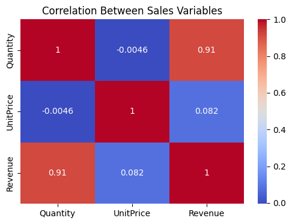

```python
corr_matrix = df[["Quantity", "UnitPrice", "Revenue"]].corr()

plt.figure(figsize=(6,4))
sns.heatmap(corr_matrix, annot=True, cmap="coolwarm")

plt.title("Correlation Between Sales Variables")

plt.show()
```

Revenue shows a strong positive relationship with quantity sold, indicating that sales volume plays a major role in driving total revenue.

### Top Countries By Revenue

```python
country_sales = df.groupby("Country")["Revenue"].sum().sort_values(ascending=False)
country_sales.head(10)
```

```
Country
United Kingdom    7285024.644
Netherlands        285446.340
EIRE               265262.460
Germany            228678.400
France             208934.310
Australia          138453.810
Spain               61558.560
Switzerland         56443.950
Belgium             41196.340
Sweden              38367.830
Name: Revenue, dtype: float64
```

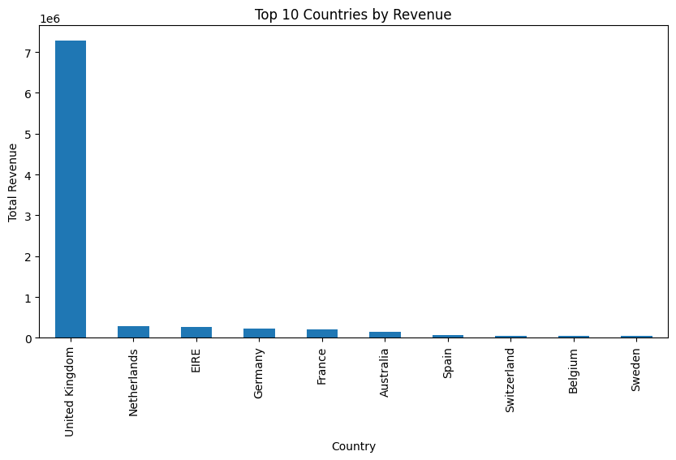

```python
country_sales.head(10).plot(kind="bar", figsize=(10,5))

plt.title("Top 10 Countries by Revenue")
plt.xlabel("Country")
plt.ylabel("Total Revenue")

plt.show()
```

The United Kingdom contributes the largest share of total revenue, indicating that the business heavily relies on this market.

### Top Customers by Revenue

```python
top_customers = df.groupby("CustomerID")["Revenue"].sum().sort_values(ascending=False).head(10)
top_customers
```

```
CustomerID
14646    280206.02
18102    259657.30
17450    194390.79
16446    168472.50
14911    143711.17
12415    124914.53
14156    117210.08
17511     91062.38
16029     80850.84
12346     77183.60
Name: Revenue, dtype: float64
```

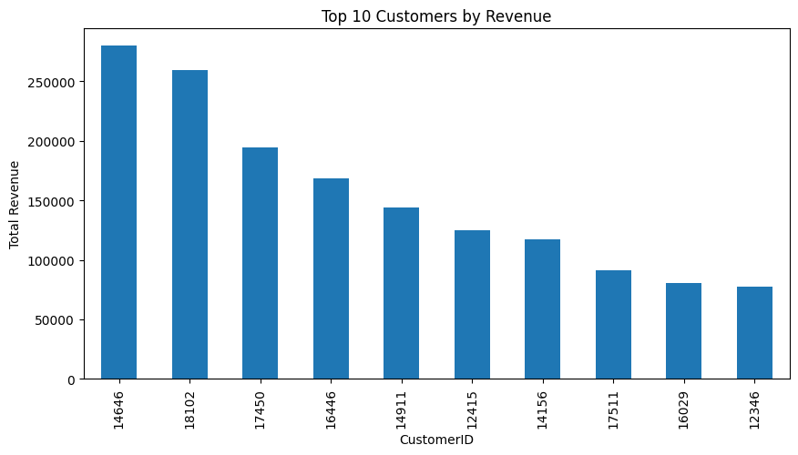

```python
top_customers.plot(kind="bar", figsize=(10,5))
plt.title("Top 10 Customers by Revenue")
plt.xlabel("CustomerID")
plt.ylabel("Total Revenue")

plt.show()
```

Customer 14646 and 18102 generate the highest revenue, showing that a few high-value customers contribute significantly to total sales.

### Average Order Value

```python
aov = df.groupby("InvoiceNo")["Revenue"].sum().mean()
print("Average Order Value:", aov)
```

```
Average Order Value: 479.56016047917126
```

The average order value is approximately 479, indicating the typical amount customers spend per purchase.

### Cancellation Analysis

```python
cancelled_orders = df[df["InvoiceNo"].astype(str).str.startswith("C")]

total_orders = df["InvoiceNo"].nunique()
cancel_orders = cancelled_orders["InvoiceNo"].nunique()

print("Total Orders:", total_orders)
print("Cancelled Orders:", cancel_orders)
print("Cancellation Rate:", cancel_orders / total_orders * 100, "%")
```

```
Total Orders: 18532
Cancelled Orders: 0
Cancellation Rate: 0.0 %
```

### Top Products By Revenue

```python
product_sales = df.groupby("Description")["Revenue"].sum().sort_values(ascending=False)
product_sales.head(10)
```

```
Description
PAPER CRAFT , LITTLE BIRDIE           168469.60
REGENCY CAKESTAND 3 TIER              142264.75
WHITE HANGING HEART T-LIGHT HOLDER    100392.10
JUMBO BAG RED RETROSPOT                85040.54
MEDIUM CERAMIC TOP STORAGE JAR         81416.73
POSTAGE                                77803.96
PARTY BUNTING                          68785.23
ASSORTED COLOUR BIRD ORNAMENT          56413.03
Manual                                 53419.93
RABBIT NIGHT LIGHT                     51251.24
Name: Revenue, dtype: float64
```

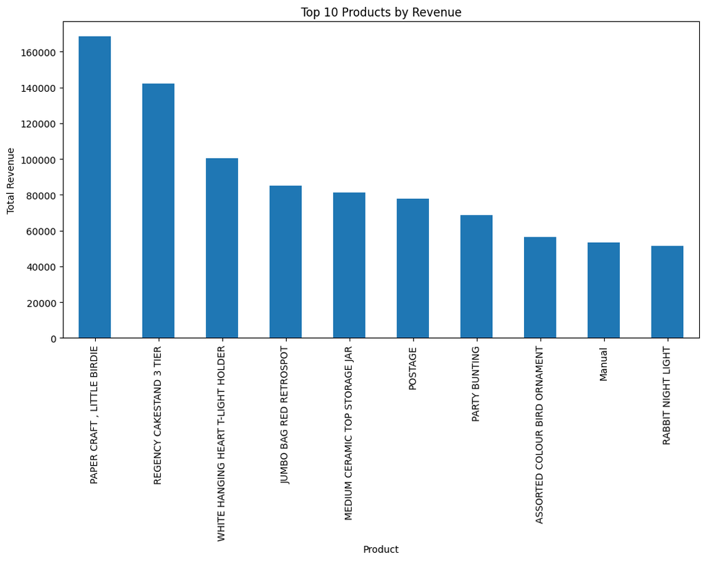

```python
product_sales.head(10).plot(kind="bar", figsize=(12,6))

plt.title("Top 10 Products by Revenue")
plt.xlabel("Product")
plt.ylabel("Total Revenue")

plt.show()
```

Products like PAPER CRAFT LITTLE BIRDIE and REGENCY CAKESTAND generate the highest revenue, showing that a few popular products contribute significantly to total sales.

### Monthly Revenue Trend

```python
df["InvoiceDate"] = pd.to_datetime(df["InvoiceDate"], dayfirst=True)

df["Month"] = df["InvoiceDate"].dt.to_period("M")

monthly_sales = df.groupby("Month")["Revenue"].sum()
monthly_sales.head()
```

```
Month
2010-12    570422.730
2011-01    568101.310
2011-02    446084.920
2011-03    594081.760
2011-04    468374.331
Freq: M, Name: Revenue, dtype: float64
```

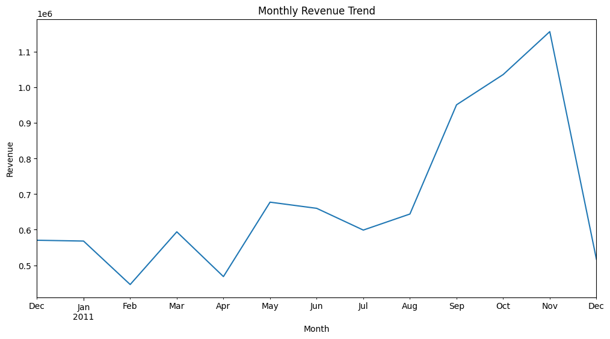

```python
monthly_sales.plot(figsize=(12,6))
plt.title("Monthly Revenue Trend")
plt.xlabel("Month")
plt.ylabel("Revenue")
plt.show()
```

Revenue shows an increasing trend toward the end of the year, indicating higher sales during the holiday season.

### Customer Segmentation (RFM Analysis)

```python
snapshot_date = df["InvoiceDate"].max() + pd.Timedelta(days=1)
snapshot_date
rfm = df.groupby("CustomerID").agg({
    "InvoiceDate": lambda x: (snapshot_date - x.max()).days,
    "InvoiceNo": "count",
    "Revenue": "sum"
})

rfm.columns = ["Recency", "Frequency", "Monetary"]

rfm.head()
```

| CustomerID | Recency | Frequency | Monetary |
| --- | --- | --- | --- |
| 12346 | 326 | 1 | 77183.60 |
| 12347 | 2 | 182 | 4310.00 |
| 12348 | 75 | 31 | 1797.24 |
| 12349 | 19 | 73 | 1757.55 |
| 12350 | 310 | 17 | 334.40 |

```python
r_labels = range(4,0,-1)
f_labels = range(1,5)
m_labels = range(1,5)
rfm["R"] = pd.qcut(rfm["Recency"],4,labels=r_labels)
rfm["F"] = pd.qcut(rfm["Frequency"],4,labels=f_labels)
rfm["M"] = pd.qcut(rfm["Monetary"],4,labels=m_labels)

rfm.head()
rfm["RFM_Score"] = rfm["R"].astype(int) + rfm["F"].astype(int) + rfm["M"].astype(int)
rfm.head()
```

| CustomerID | Recency | Frequency | Monetary | R | F | M | RFM_Score |
| --- | --- | --- | --- | --- | --- | --- | --- |
| 12346 | 326 | 1 | 77183.60 | 1 | 1 | 4 | 6 |
| 12347 | 2 | 182 | 4310.00 | 4 | 4 | 4 | 12 |
| 12348 | 75 | 31 | 1797.24 | 2 | 2 | 4 | 8 |
| 12349 | 19 | 73 | 1757.55 | 3 | 3 | 4 | 10 |
| 12350 | 310 | 17 | 334.40 | 1 | 1 | 2 | 4 |

RFM scores help identify valuable customers based on their recent purchases, purchase frequency, and total spending.

```python
def segment_customer(row):

    if row["R"] == 4 and row["F"] >= 3:
        return "Champions"

    elif row["R"] >= 3 and row["F"] >= 3:
        return "Loyal Customers"

    elif row["R"] >= 3 and row["F"] <= 2:
        return "Potential Loyalists"

    elif row["R"] == 2:
        return "At Risk"

    else:
        return "Lost Customers"

rfm["Segment"] = rfm.apply(segment_customer, axis=1)

rfm.head()
```

| CustomerID | Recency | Frequency | Monetary | R | F | M | RFM_Score | Segment |
| --- | --- | --- | --- | --- | --- | --- | --- | --- |
| 12346 | 326 | 1 | 77183.60 | 1 | 1 | 4 | 6 | Lost Customers |
| 12347 | 2 | 182 | 4310.00 | 4 | 4 | 4 | 12 | Champions |
| 12348 | 75 | 31 | 1797.24 | 2 | 2 | 4 | 8 | At Risk |
| 12349 | 19 | 73 | 1757.55 | 3 | 3 | 4 | 10 | Loyal Customers |
| 12350 | 310 | 17 | 334.40 | 1 | 1 | 2 | 4 | Lost Customers |

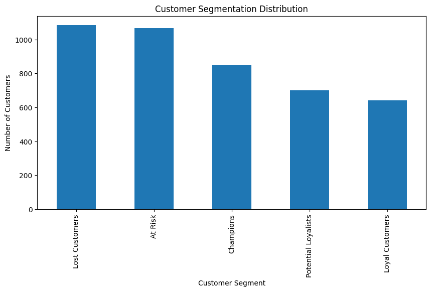

```python
rfm["Segment"].value_counts().plot(kind="bar", figsize=(10,5))

plt.title("Customer Segmentation Distribution")
plt.xlabel("Customer Segment")
plt.ylabel("Number of Customers")

plt.show()
```

### Conclusion

This analysis provided insights into sales performance, customer behavior, and revenue trends. A few products and customers contribute significantly to total revenue, while sales increase toward the end of the year indicating seasonal demand. RFM segmentation highlights different customer groups, helping businesses focus on retaining loyal customers and re-engaging at-risk customers.